# Econometrics II - Problem 4

William Radaic Peron

In this problem, we’ll be tackling the issue of *forecasting* of an ARMA model. The problem is split in two parts: (i) *cross-validation*; and (ii) *bootstrapping*.

First, let’s identify the best model for our time series.

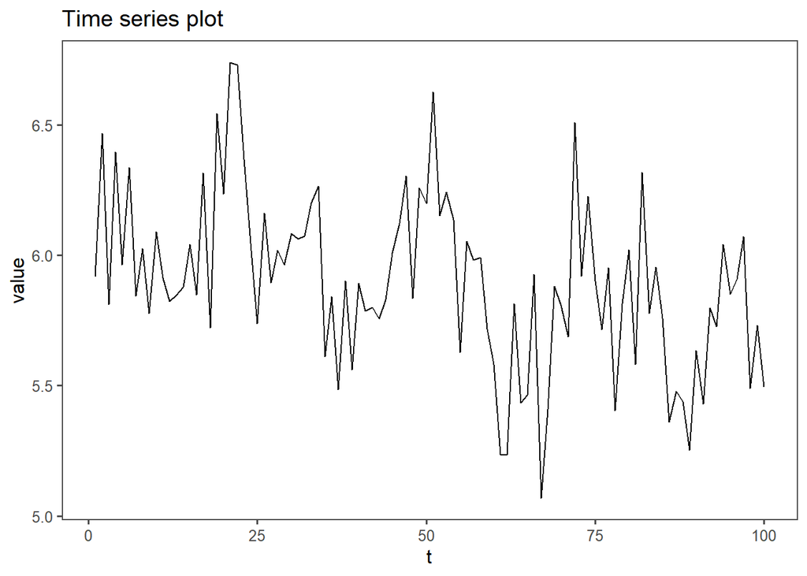

```r
df <- data.frame(df)

pplot <- ggplot(data = df, aes(x = t, y = value)) + geom_line() + ggtitle("Time series plot") + theme_few()
pplot
```

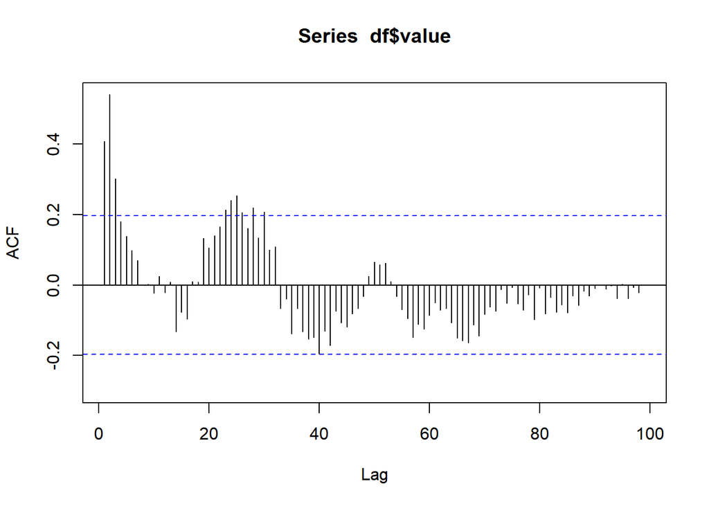

```r
acf_ts <- Acf(df$value, lag.max = 5000)
```

```r
acf_test_values <- acf_ts$acf/sd(acf_ts$acf)

head(data.frame(acf_test_values))
```

```
##   acf_test_values
## 1        6.176432
## 2        2.515951
## 3        3.335438
## 4        1.864909
## 5        1.112884
## 6        0.858639
```

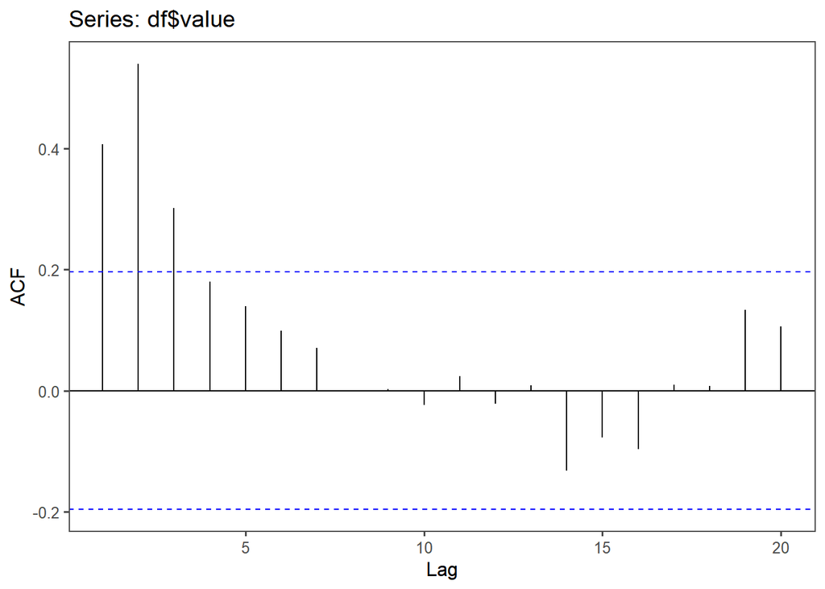

```r
facst <- ggAcf(df$value, type = "correlation", lag.max = 20, plot = T) + theme_few()
faclt <- ggAcf(df$value, type = "correlation", lag.max = 5000, plot = T) + theme_few()

facpst <- ggPacf(df$value, type = "correlation", lag.max = 100, plot = T) + theme_few()
facplt <- ggPacf(df$value, type = "correlation", lag.max = 5000, plot = T) + theme_few()
facst
```

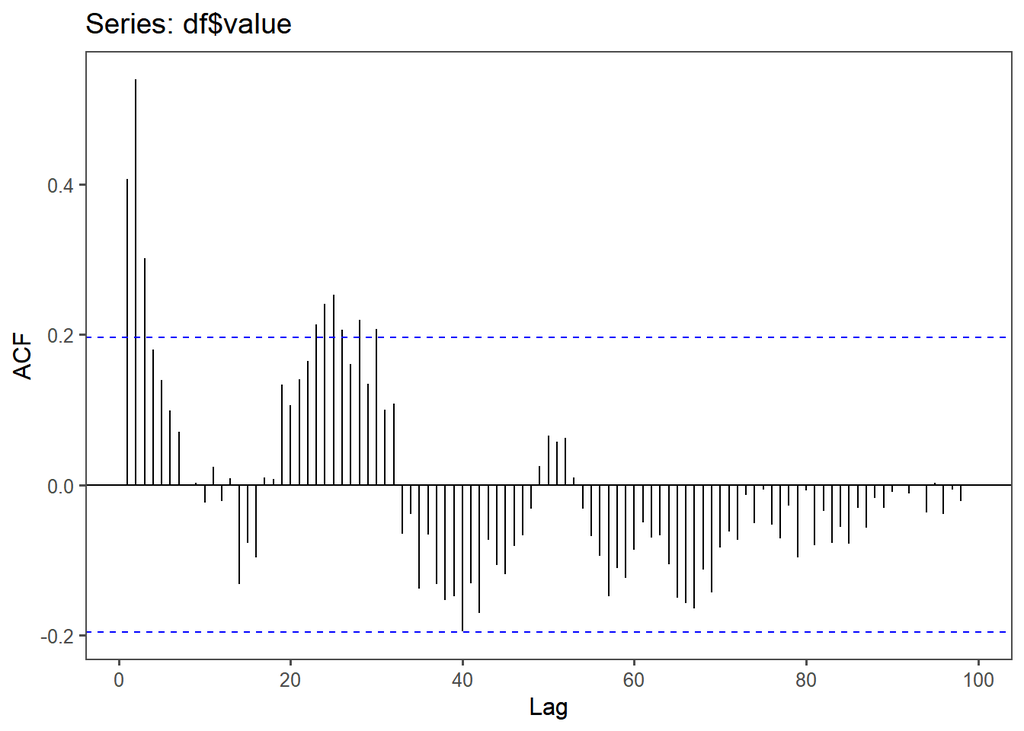

```r
faclt
```

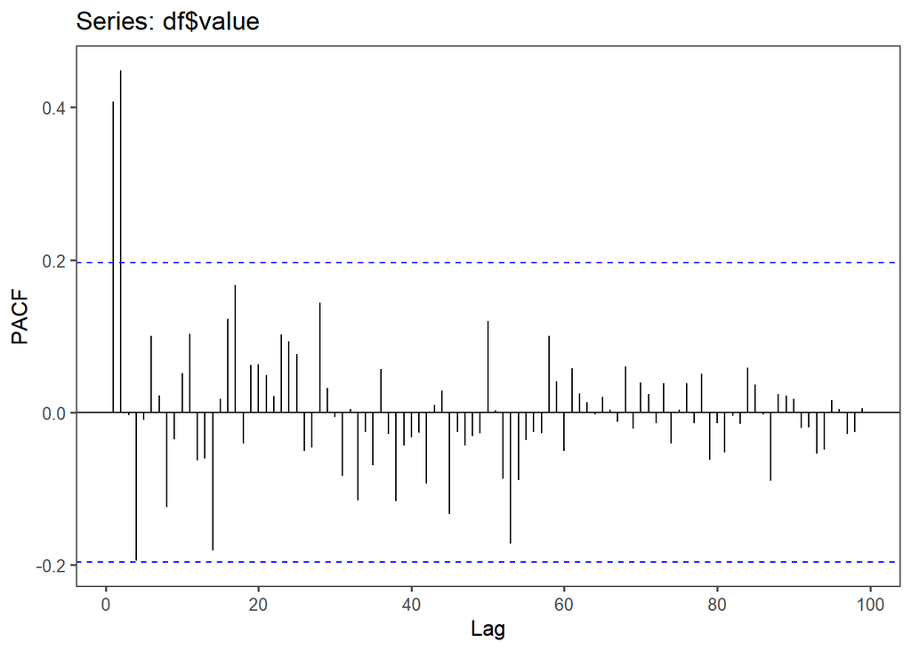

```r
facpst
```

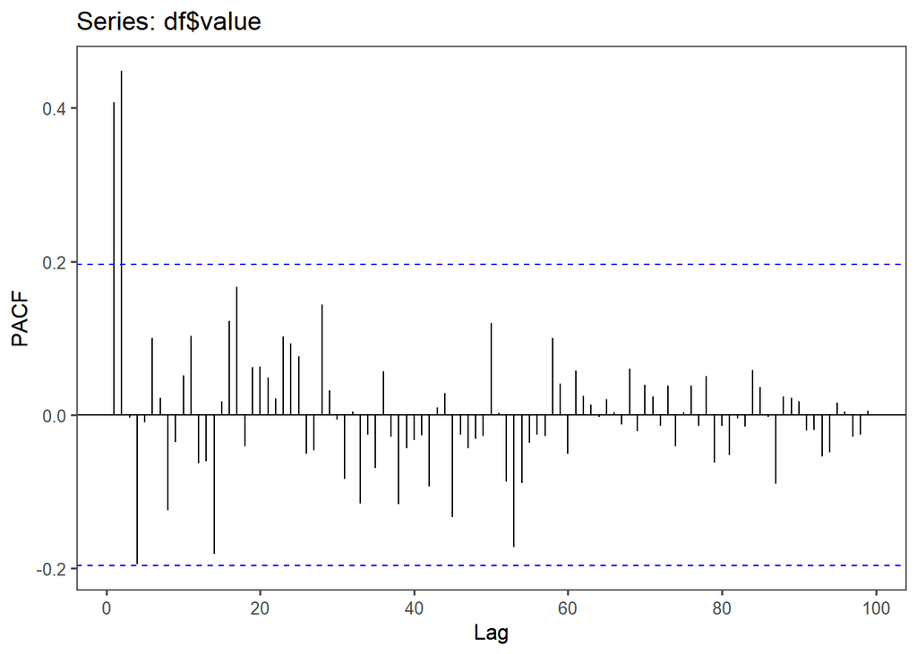

```r
facplt
```

We’ll now use the function *auto.arima* from the package *forecast* to identify and estimate the model.

```r
aa_model <- auto.arima(df$value, num.cores = 24, max.d = 0, stepwise = F)

summary(aa_model)
```

```
## Series: df$value
## ARIMA(0,0,3) with non-zero mean
##
## Coefficients:
##          ma1     ma2     ma3    mean
##       0.1814  0.6647  0.4001  5.8982
## s.e.  0.0852  0.0750  0.0949  0.0562
##
## sigma^2 estimated as 0.0667:  log likelihood=-5.42
## AIC=20.85   AICc=21.49   BIC=33.88
##
## Training set error measures:
##                        ME      RMSE       MAE        MPE     MAPE      MASE
## Training set -0.002315954 0.2530428 0.2131067 -0.2268814 3.612855 0.7314965
##                    ACF1
## Training set 0.03868106
```

```r
print("t-values: ")
```

```
## [1] "t-values: "
```

```r
aa_t <- matrix(NA, nrow = aa_model$arma[1] + aa_model$arma[2])

for (i in c(1:4)) {

aa_t[i] <- aa_model$coef[i]/sqrt(aa_model$var.coef[i,i])

}

aa_t <- data.frame(aa_t)

aa_t
```

```
##         aa_t
## 1   2.128691
## 2   8.861580
## 3   4.216481
## 4 105.004537
```

```r
aa_q <- Box.test(aa_model$residuals, lag = aa_model$arma[1] + aa_model$arma[2])
aa_q
```

```
##
##  Box-Pierce test
##
## data:  aa_model$residuals
## X-squared = 0.35002, df = 3, p-value = 0.9504
```

```r
criteria <- matrix(NA, nrow = 1, ncol = 3)

aa_criteria <- data.frame("MA(3)*", aa_model$aic, aa_model$bic)

names(aa_criteria) <- c("Model", "AIC", "BIC")

aa_criteria
```

```
##    Model      AIC      BIC
## 1 MA(3)* 20.84963 33.87549
```

```r
fac_e <- ggAcf(aa_model$residuals, type = "correlation", lag.max = 20, plot = T) + theme_few()

facp_e <- ggPacf(aa_model$residuals, type = "correlation", lag.max = 20, plot = T) + theme_few()
```

The results of *auto.arima* imply that the best model is an ARMA(0,3) – i.e., a MA(3):
$$y_t = c + + \theta_1 \varepsilon_{t-1} + \theta_2 \varepsilon_{t-2}+ \theta_3 \varepsilon_{t-3} + \varepsilon_t, \hspace{1em} \varepsilon_t \sim wn(0, \sigma^2)$$

Furthermore, the Q-statistic *(Box.test)* seems to indicate that $\varepsilon_t$ is truly white noise.

Let $h := 5$; $frac = 0.2$. $T$ is the size of our sample; $k$ is the *training* database. The remainder shall be used for testing purposes.

As we have discovered previously, *auto.arima* yields a **MA(3)** model. It will now be used.

```r
h <- 5

frac <- 0.2

T <- length(df$value)

k <- floor((1-frac)*T)

# Estimating MA(3) with k = 80
fit <- Arima(df$value[1:k], order = c(0,0,3))

# Generating predictions from the model
pred <- predict(fit, n.ahead = h)

# Calculating errors between the predicted values of the model and the actual values of the testing database

e <- df$value[(k+h)] - pred$pred[h]

e
```

```
## [1] -0.1951299
```

Let’s now update our training database iteratively with a for loop.

```r
e <- matrix(NA, nrow = 100)

# Updating the model

for (i in k:(T-h)) {

  fit <- Arima(df$value[1:i], order = c(0,0,3))

  pred <- predict(fit, n.ahead = h)

  e[i,1] <- df$value[(i+h)] - pred$pred[h]

}
```

With the matrix *e* in hands, we can now calculate MSE:

```r
mse <- mean(e^2, na.rm = T)
```

This procedure can now be used to compare other models against the model from *auto.arima*.

```r
max_p <- 5

max_q <- 5

e <- matrix(NA, nrow = 100, ncol = (max_p + 1) * (max_q + 1))

pred <- vector("list", (max_p + 1) * (max_q + 1))

fit <- vector("list", (max_p + 1) * (max_q + 1))

# Updating the model
for (u in 0:max_q) {

for (j in 0:max_p) {


  for (i in k:(T-h)) {

 fit[[(((max_p+1)*j)+u + 1)]] <- Arima(df$value[1:i], order = c(j,0,u))

#  fit <- append(fit, Arima(df$value[1:i], order = c(j,0,u)))

# pred <- append(pred, predict(fit[[(j+u)]], n.ahead = h))

 pred[[(((max_p+1)*j)+u + 1)]] <- predict(fit[[(((max_p+1)*j)+u + 1)]], n.ahead = h)

 e[i,(((max_p+1)*j)+u + 1)] <- df$value[(i+h)] - pred[[(((max_p+1)*j)+u + 1)]]$pred[h]

  }

}

}

mse <- matrix(NA, nrow = ((max_p + 1) * (max_q + 1)), ncol = 1)




mse <- colMeans(e^2, na.rm = T)

mse
```

```
##  [1] 0.1357466 0.1354001 0.1368083 0.1374243 0.1376508 0.1441940 0.1347115
##  [8] 0.1269779 0.1347789 0.1373465 0.1398588 0.1436175 0.1313779 0.1315448
## [15] 0.1435805 0.1355649 0.1421277 0.1335153 0.1316765 0.1333955 0.1400838
## [22] 0.1427467 0.1473227 0.1347447 0.1320856 0.1333025 0.1354734 0.1341742
## [29] 0.1380676 0.1357880 0.1346228 0.1382810 0.1319484 0.1308446 0.1382417
## [36] 0.1327046
```

```r
optimal_index <- which.min(mse)

cv_model <- fit[[optimal_index]]
```

Estimate ARMA(p,q)
$$Y_t = c + \sum_{j=1}^p \phi_j Y_{t-j} + \sum_{j=1}^q \theta_j \varepsilon_{t-j} + \varepsilon_t$$

Calculate the residuals of the regression:

$$\hat{\varepsilon}_t := Y_t - (\hat{c} + \sum_{j=1}^p \hat{\phi}_j Y_{t-j} + \sum_{j=1}^q \hat{\theta}_j \varepsilon_{t-j})$$

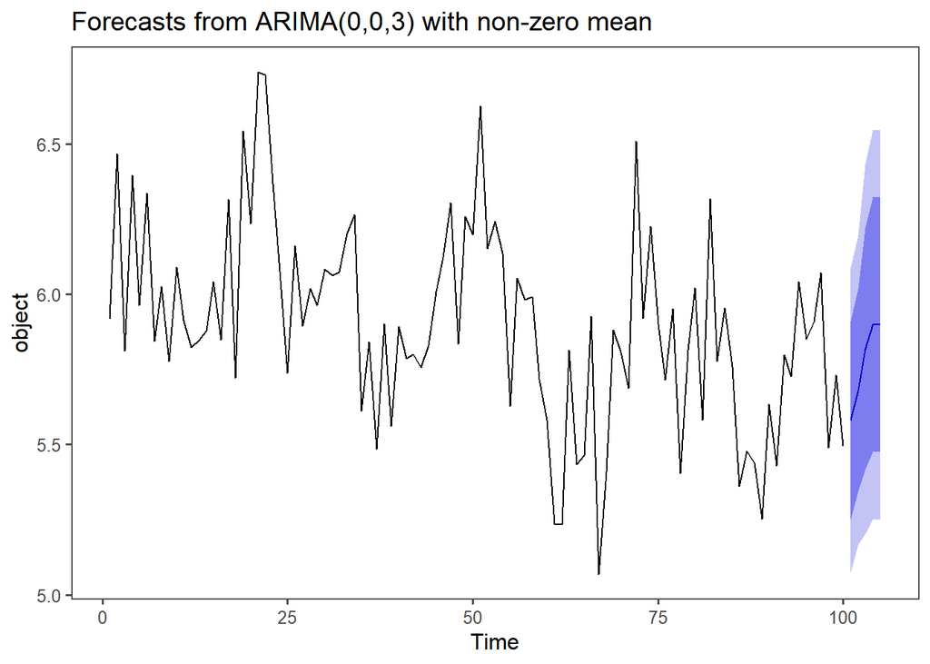

```r
fc <- forecast(df$value, model = aa_model, h = h)

autoplot(fc) + theme_few()
```

```r
summary(fc)
```

```
##
## Forecast method: ARIMA(0,0,3) with non-zero mean
##
## Model Information:
## Series: object
## ARIMA(0,0,3) with non-zero mean
##
## Coefficients:
##          ma1     ma2     ma3    mean
##       0.1814  0.6647  0.4001  5.8982
## s.e.  0.0000  0.0000  0.0000  0.0000
##
## sigma^2 estimated as 0.0667:  log likelihood=-5.42
## AIC=12.85   AICc=12.89   BIC=15.45
##
## Error measures:
##                        ME      RMSE       MAE        MPE     MAPE      MASE
## Training set -0.002315954 0.2530428 0.2131067 -0.2268814 3.612855 0.7314965
##                    ACF1
## Training set 0.03868106
##
## Forecasts:
##     Point Forecast    Lo 80    Hi 80    Lo 95    Hi 95
## 101       5.580698 5.249724 5.911673 5.074517 6.086880
## 102       5.681504 5.345129 6.017879 5.167063 6.195945
## 103       5.816823 5.414896 6.218750 5.202129 6.431517
## 104       5.898184 5.475000 6.321368 5.250980 6.545387
## 105       5.898184 5.475000 6.321368 5.250980 6.545387
```